# Varroa sup1

We can do a simple plot of our results.

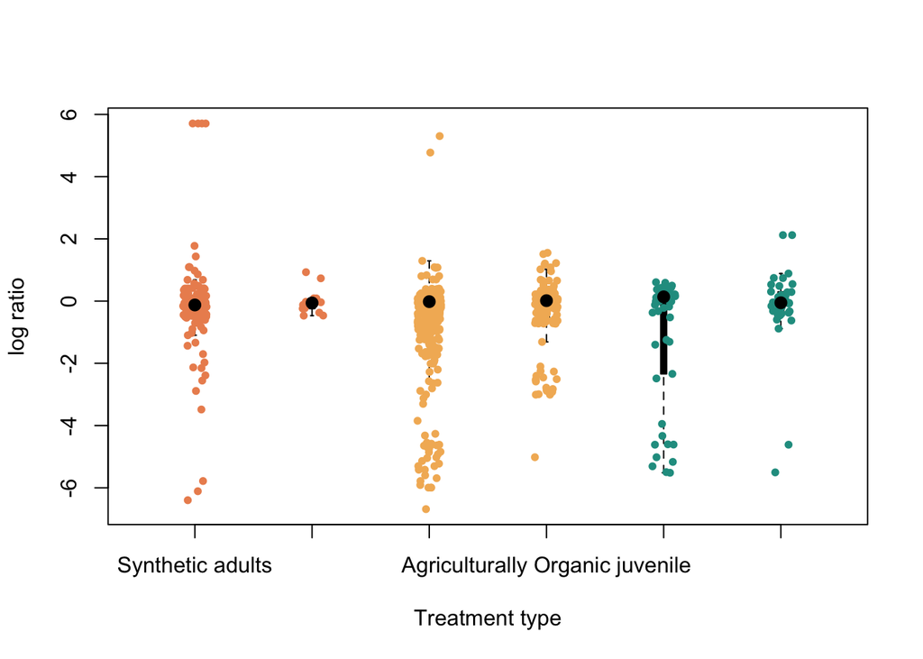

```r
plot(life_bees_data$logratio ~ life_bees_data$life_treat,
     col ="black",
     bty = "n",
     boxwex = 0.05,
     ylab = "log ratio",
     xlab = "Treatment type",
     pch = 16,
     cex = 0,
     names = c("Synthetic adults",
               "Synthetic juvenile",
               "Agriculturally Organic worker",
               "Agriculturally Organic juvenile",
               "Biological adults",
               "Biological juvenile"))


#We can plot the points for Synthetic_Honey_bee_worker
points(life_bees_data[life_bees_data$life_treat == "Synthetic_Honey_bee_worker", "logratio"] ~
         jitter(as.integer(life_bees_data[life_bees_data$life_treat == "Synthetic_Honey_bee_worker",                                           "life_treat"]),
                  amount = 0.1),
       pch = 16,
       col = rgb(236, 143, 94, max=255),
       cex = 0.8)

points(hdr(life_bees_data[life_bees_data$life_treat == "Synthetic_Honey_bee_worker",
                       "logratio"])$mode
       ~ c(1),
       pch = 16,
       col = "black",
       cex = 1.3)


#We can plot the points for Synthetic_Honey_bee_juvenile
points(life_bees_data[life_bees_data$life_treat == "Synthetic_Honey_bee_juvenile",
                      "logratio"] ~
         jitter(as.integer(life_bees_data[life_bees_data$life_treat == "Synthetic_Honey_bee_juvenile", "life_treat"]),
                  amount = 0.1),
       pch = 16,
       col = rgb(236, 143, 94, max=255),
       cex = 0.8)

points(hdr(life_bees_data[life_bees_data$life_treat == "Synthetic_Honey_bee_juvenile",
                       "logratio"])$mode
       ~ c(2),
       pch = 16,
       col = "black",
       cex = 1.3)



#We can plot the points for Agriculturally_Organic_Honey_bee_worker
points(life_bees_data[life_bees_data$life_treat == "Agriculturally_Organic_Honey_bee_worker",
                      "logratio"] ~
         jitter(as.integer(life_bees_data[life_bees_data$life_treat == "Agriculturally_Organic_Honey_bee_worker", "life_treat"]),
                  amount = 0.1),
       pch = 16,
       col = rgb(243, 182, 100, max=255),
       cex = 0.8)

points(hdr(life_bees_data[life_bees_data$life_treat == "Agriculturally_Organic_Honey_bee_worker",
                       "logratio"])$mode
       ~ c(3),
       pch = 16,
       col = "black",
       cex = 1.3)




#We can plot the points for Agriculturally_Organic_Honey_bee_juvenile
points(life_bees_data[life_bees_data$life_treat == "Agriculturally_Organic_Honey_bee_juvenile",
                      "logratio"] ~
         jitter(as.integer(life_bees_data[life_bees_data$life_treat == "Agriculturally_Organic_Honey_bee_juvenile", "life_treat"]),
                  amount = 0.1),
       pch = 16,
       col = rgb(243, 182, 100, max=255),
       cex = 0.8)

points(hdr(life_bees_data[life_bees_data$life_treat == "Agriculturally_Organic_Honey_bee_juvenile",
                       "logratio"])$mode
       ~ c(4),
       pch = 16,
       col = "black",
       cex = 1.3)




#We can plot the points for Biological_Honey_bee_worker
points(life_bees_data[life_bees_data$life_treat == "Biological_Honey_bee_worker",
                      "logratio"] ~
         jitter(as.integer(life_bees_data[life_bees_data$life_treat == "Biological_Honey_bee_worker", "life_treat"]),
                  amount = 0.1),
       pch = 16,
       col = rgb(33, 156, 144, max=255),
       cex = 0.8)

points(hdr(life_bees_data[life_bees_data$life_treat == "Biological_Honey_bee_worker",
                       "logratio"])$mode
       ~ c(5),
       pch = 16,
       col = "black",
       cex = 1.3)




#We can plot the points for Biological_Honey_bee_juvenile
points(life_bees_data[life_bees_data$life_treat == "Biological_Honey_bee_juvenile",
                      "logratio"] ~
         jitter(as.integer(life_bees_data[life_bees_data$life_treat == "Biological_Honey_bee_juvenile", "life_treat"]),
                  amount = 0.1),
       pch = 16,
       col = rgb(33, 156, 144, max=255),
       cex = 0.8)

points(hdr(life_bees_data[life_bees_data$life_treat == "Biological_Honey_bee_juvenile",
                       "logratio"])$mode
       ~ c(6),
       pch = 16,
       col = "black",
       cex = 1.3)
```

# Supplementary analaysis

We can also look at the main model when split into just studies measruing increases in bees, which is for 44 studies for this analysis

```r
mod_HoneyBeeIncrease <- MCMCglmm(logratio ~ chem_split + Context,
                                 rcov=~units,
                                 random =~StudyID_control
                                          + Continent
                                          + Cont_Country,
                                 family ="gaussian",
                                 data = HoneyBeeIncrease_paired_fin,
                                 nitt = nitt,
                                 thin = thining,
                                 burnin = burnin,
                                 prior = prior_d,
                                 verbose = FALSE
                            )

mod_HoneyBeeIncrease2 <- MCMCglmm(logratio ~ chem_split + Context,
                                 rcov=~units,
                                 random =~StudyID_control
                                          + Continent
                                          + Cont_Country,
                                 family ="gaussian",
                                 data = HoneyBeeIncrease_paired_fin,
                                 nitt = nitt,
                                 thin = thining,
                                 burnin = burnin,
                                 prior = prior_d,
                                 verbose = FALSE
                            )

mod_HoneyBeeIncrease3 <- MCMCglmm(logratio ~ chem_split + Context,
                                 rcov=~units,
                                 random =~StudyID_control
                                          + Continent
                                          + Cont_Country,
                                 family ="gaussian",
                                 data = HoneyBeeIncrease_paired_fin,
                                 nitt = nitt,
                                 thin = thining,
                                 burnin = burnin,
                                 prior = prior_d,
                                 verbose = FALSE
                            )

#Check the fixed terms
mod_HoneyBeeIncrease_Sol_conv <- gelman.diag(mcmc.list(mod_HoneyBeeIncrease$Sol,
                                       mod_HoneyBeeIncrease2$Sol,
                                       mod_HoneyBeeIncrease3$Sol))
mod_HoneyBeeIncrease_Sol_conv
```

```
## Potential scale reduction factors:
##
##                                  Point est. Upper C.I.
## (Intercept)                            1.01       1.01
## chem_splitAgriculturally_Organic       1.00       1.00
## chem_splitBiological                   1.00       1.00
## chem_splitPhysical                     1.00       1.00
## chem_splitMixed                        1.00       1.00
## ContextLab                             1.00       1.01
##
## Multivariate psrf
##
## 1
```

```r
#Check the random terms
mod_HoneyBeeIncrease_VCV_conv <- gelman.diag(mcmc.list(mod_HoneyBeeIncrease$VCV,
                                       mod_HoneyBeeIncrease2$VCV,
                                       mod_HoneyBeeIncrease3$VCV))
mod_HoneyBeeIncrease_VCV_conv
```

```
## Potential scale reduction factors:
##
##                 Point est. Upper C.I.
## StudyID_control       1.00       1.00
## Continent             1.02       1.02
## Cont_Country          1.00       1.00
## units                 1.00       1.00
##
## Multivariate psrf
##
## 1
```

```r
summary(mod_HoneyBeeIncrease)
```

```
##
##  Iterations = 10001:109951
##  Thinning interval  = 50
##  Sample size  = 2000
##
##  DIC: 647.9776
##
##  G-structure:  ~StudyID_control
##
##                 post.mean l-95% CI u-95% CI eff.samp
## StudyID_control    0.1387  0.04302   0.2559     2213
##
##                ~Continent
##
##           post.mean  l-95% CI u-95% CI eff.samp
## Continent    0.2849 1.079e-06   0.9651     1861
##
##                ~Cont_Country
##
##              post.mean l-95% CI u-95% CI eff.samp
## Cont_Country   0.06043 6.54e-08   0.1907     2000
##
##  R-structure:  ~units
##
##       post.mean l-95% CI u-95% CI eff.samp
## units    0.2205   0.1924   0.2527     2000
##
##  Location effects: logratio ~ chem_split + Context
##
##                                  post.mean l-95% CI u-95% CI eff.samp pMCMC
## (Intercept)                       -0.11008 -0.67985  0.39384     2000 0.584
## chem_splitAgriculturally_Organic   0.16757  0.03537  0.31006     2357 0.020 *
## chem_splitBiological               0.48638  0.17869  0.79671     1849 0.002 **
## chem_splitPhysical                 0.28930 -0.24618  0.81371     1774 0.279
## chem_splitMixed                   -0.03204 -1.16541  0.99793     2080 0.967
## ContextLab                         0.32248 -0.22929  0.87692     2000 0.245
## ---
## Signif. codes:  0 '***' 0.001 '**' 0.01 '*' 0.05 '.' 0.1 ' ' 1
```

While not significant synthetic chemicals have weak support for a negative effect on bee pops, but organic chemical have a significantly positive effect compared to synthetic chemicals. This difference shows that organic chemicals have a neutral effect on bee pops while synthetic are likely worse than controls.Biological treatments have a positive effect on bee pops at a ratio of 1.6/1 with no other significant effects.

# Studies that measure a decrease bee pops

This is with the original data so a positive value here is something that decreases bee pops and health. There is 36 studies here.

```r
mod_HoneyBeeReduction <- MCMCglmm(logratio ~ chem_split + Context,
                                 rcov=~units,
                                 random =~StudyID_control
                                          + Continent
                                          + Cont_Country,
                                 family ="gaussian",
                                 data = HoneyBeeReduction_paired_fin,
                                 nitt = nitt,
                                 thin = thining,
                                 burnin = burnin,
                                 prior = prior_d,
                                 verbose = FALSE
                            )
mod_HoneyBeeReduction2 <- MCMCglmm(logratio ~ chem_split + Context,
                                 rcov=~units,
                                 random =~StudyID_control
                                          + Continent
                                          + Cont_Country,
                                 family ="gaussian",
                                 data = HoneyBeeReduction_paired_fin,
                                 nitt = nitt,
                                 thin = thining,
                                 burnin = burnin,
                                 prior = prior_d,
                                 verbose = FALSE
                            )
mod_HoneyBeeReduction3 <- MCMCglmm(logratio ~ chem_split + Context,
                                 rcov=~units,
                                 random =~StudyID_control
                                          + Continent
                                          + Cont_Country,
                                 family ="gaussian",
                                 data = HoneyBeeReduction_paired_fin,
                                 nitt = nitt,
                                 thin = thining,
                                 burnin = burnin,
                                 prior = prior_d,
                                 verbose = FALSE
                            )
#Check the fixed terms
mod_HoneyBeeReduction_Sol_conv<- gelman.diag(mcmc.list(mod_HoneyBeeReduction$Sol,
                                       mod_HoneyBeeReduction2$Sol,
                                       mod_HoneyBeeReduction3$Sol))
mod_HoneyBeeReduction_Sol_conv
```

```
## Potential scale reduction factors:
##
##                                  Point est. Upper C.I.
## (Intercept)                               1          1
## chem_splitAgriculturally_Organic          1          1
## chem_splitBiological                      1          1
## chem_splitMixed                           1          1
## ContextLab                                1          1
##
## Multivariate psrf
##
## 1
```

```r
#Check the random terms
mod_HoneyBeeReduction_VCV_conv <- gelman.diag(mcmc.list(mod_HoneyBeeReduction$VCV,
                                       mod_HoneyBeeReduction2$VCV,
                                       mod_HoneyBeeReduction3$VCV))
mod_HoneyBeeReduction_VCV_conv
```

```
## Potential scale reduction factors:
##
##                 Point est. Upper C.I.
## StudyID_control       1.00       1.00
## Continent             1.02       1.02
## Cont_Country          1.00       1.00
## units                 1.00       1.00
##
## Multivariate psrf
##
## 1
```

```r
summary(mod_HoneyBeeReduction)
```

```
##
##  Iterations = 10001:109951
##  Thinning interval  = 50
##  Sample size  = 2000
##
##  DIC: 1272.668
##
##  G-structure:  ~StudyID_control
##
##                 post.mean l-95% CI u-95% CI eff.samp
## StudyID_control     1.968   0.7749    3.493     2256
##
##                ~Continent
##
##           post.mean  l-95% CI u-95% CI eff.samp
## Continent    0.9235 4.203e-08    3.736     2000
##
##                ~Cont_Country
##
##              post.mean l-95% CI u-95% CI eff.samp
## Cont_Country    0.4859 1.36e-07     1.85     2000
##
##  R-structure:  ~units
##
##       post.mean l-95% CI u-95% CI eff.samp
## units     2.824     2.36    3.287     2000
##
##  Location effects: logratio ~ chem_split + Context
##
##                                  post.mean l-95% CI u-95% CI eff.samp pMCMC
## (Intercept)                         1.7029   0.2534   3.1098     2000 0.027 *
## chem_splitAgriculturally_Organic   -0.7201  -1.7594   0.2953     2000 0.161
## chem_splitBiological               -0.3458  -1.8958   1.3521     2214 0.683
## chem_splitMixed                    -1.9430  -5.3852   1.0978     2000 0.240
## ContextLab                         -0.2888  -1.2628   0.6911     2000 0.556
## ---
## Signif. codes:  0 '***' 0.001 '**' 0.01 '*' 0.05 '.' 0.1 ' ' 1
```

We find no significant effects, likely due to the low sample size.

# Studies that measure a decreases in varroa pops

Analysis just including measures of Varroa decreases.

```r
mod_VarroaReduction <- MCMCglmm(logratio ~ chem_split + Context,
                                 rcov=~units,
                                 random =~StudyID_control
                                          + Continent
                                          + Cont_Country,
                                 family ="gaussian",
                                 data = VarroaReduction_paired_fin,
                                 nitt = nitt,
                                 thin = thining,
                                 burnin = burnin,
                                 prior = prior_d,
                                 verbose = FALSE)


mod_VarroaReduction2 <- MCMCglmm(logratio ~ chem_split + Context,
                                 rcov=~units,
                                 random =~StudyID_control
                                          + Continent
                                          + Cont_Country,
                                 family ="gaussian",
                                 data = VarroaReduction_paired_fin,
                                 nitt = nitt,
                                 thin = thining,
                                 burnin = burnin,
                                 prior = prior_d,
                                 verbose = FALSE)

mod_VarroaReduction3 <- MCMCglmm(logratio ~ chem_split + Context,
                                 rcov=~units,
                                 random =~StudyID_control
                                          + Continent
                                          + Cont_Country,
                                 family ="gaussian",
                                 data = VarroaReduction_paired_fin,
                                 nitt = nitt,
                                 thin = thining,
                                 burnin = burnin,
                                 prior = prior_d,
                                 verbose = FALSE)

#Check the fixed terms
mod_VarroaReduction_Sol_conv<- gelman.diag(mcmc.list(mod_VarroaReduction$Sol,
                                       mod_VarroaReduction2$Sol,
                                       mod_VarroaReduction3$Sol))
mod_VarroaReduction_Sol_conv
```

```
## Potential scale reduction factors:
##
##                                  Point est. Upper C.I.
## (Intercept)                               1       1.00
## chem_splitAgriculturally_Organic          1       1.00
## chem_splitBiological                      1       1.01
## chem_splitPhysical                        1       1.00
## chem_splitMixed                           1       1.00
## ContextLab                                1       1.00
##
## Multivariate psrf
##
## 1
```

```r
#Check the random terms
mod_VarroaReduction_VCV_conv <- gelman.diag(mcmc.list(mod_VarroaReduction$VCV,
                                       mod_VarroaReduction2$VCV,
                                       mod_VarroaReduction3$VCV))
mod_VarroaReduction_VCV_conv
```

```
## Potential scale reduction factors:
##
##                 Point est. Upper C.I.
## StudyID_control          1          1
## Continent                1          1
## Cont_Country             1          1
## units                    1          1
##
## Multivariate psrf
##
## 1
```

```r
summary(mod_VarroaReduction)
```

```
##
##  Iterations = 10001:109951
##  Thinning interval  = 50
##  Sample size  = 2000
##
##  DIC: 4401.232
##
##  G-structure:  ~StudyID_control
##
##                 post.mean l-95% CI u-95% CI eff.samp
## StudyID_control     1.144   0.7967    1.579     1855
##
##                ~Continent
##
##           post.mean  l-95% CI u-95% CI eff.samp
## Continent    0.1439 4.994e-09   0.5808     2000
##
##                ~Cont_Country
##
##              post.mean  l-95% CI u-95% CI eff.samp
## Cont_Country   0.04984 7.431e-08   0.1985     2000
##
##  R-structure:  ~units
##
##       post.mean l-95% CI u-95% CI eff.samp
## units     1.743    1.615    1.892     2000
##
##  Location effects: logratio ~ chem_split + Context
##
##                                  post.mean l-95% CI u-95% CI eff.samp pMCMC
## (Intercept)                        1.78174  1.31298  2.39155     1836 0.001 ***
## chem_splitAgriculturally_Organic  -0.12361 -0.45610  0.24716     2000 0.502
## chem_splitBiological              -0.76278 -1.56343 -0.16033     2000 0.028 *
## chem_splitPhysical                -1.17470 -2.91517  0.40080     2000 0.153
## chem_splitMixed                    0.41147 -2.55666  3.20229     2000 0.794
## ContextLab                         0.45112  0.07374  0.81959     2000 0.013 *
## ---
## Signif. codes:  0 '***' 0.001 '**' 0.01 '*' 0.05 '.' 0.1 ' ' 1
```